# Earthquake Analysis

Author

Ulric Lund

## Chi-Squared Analysis of Earthquake Magnitudes

**Abstract**: Using USGS data, we provide a statistical comparison of earthquake magnitude for California vs. Nevada, for the year 2020. We limit our analysis to earthquakes of magnitude 3 or greater, and will analyze magnitude tertiles instead of the magnitudes themselves.

### Initial data management

Required packages:

```r
library(ggplot2)
```

Here we read in the US Geological Survey’s 2020, California and Nevada earthquake data.

```r
setwd("C:/Users/ulund/OneDrive - Cal Poly/_ULDocs/Classes/STAT 331/2026-1/Handouts/Data/US Earthquakes")
load(file="CA and NV Sample.Rdata")
```

We then compute the tertiles of the earthquake magnitudes, and inspect the distribution to make sure that the coding of tertiles was done properly.

```r
tertiles <- quantile(x=CA_NV_Quakes$mag, probs=c(1/3, 2/3, 1))
CA_NV_Quakes$magTert <- ifelse(CA_NV_Quakes$mag <= tertiles[1], yes=1, no=
                          ifelse(CA_NV_Quakes$mag <= tertiles[2], yes=2, no=3))
table(CA_NV_Quakes$magTert)/nrow(CA_NV_Quakes)
```

```
    1     2     3
0.360 0.335 0.305
```

Yes. About a third of earthquakes have each of the possible tertile values.

### Descriptive statistics and graphs

Below are some contingency tables (frequency and proportion) of magnitude tertile by state.

```r
table(CA_NV_Quakes$state, CA_NV_Quakes$magTert)
```

```
              1  2  3
  California 31 23 28
  Nevada     41 44 33
```

```r
prop.table(table(CA_NV_Quakes$state, CA_NV_Quakes$magTert), margin=1)
```

```
                     1         2         3
  California 0.3780488 0.2804878 0.3414634
  Nevada     0.3474576 0.3728814 0.2796610
```

California has more small and large magnitude earthquakes than Nevada, while Nevada has more medium sized earthquakes than California.

Graphically, the same results are depicted below.

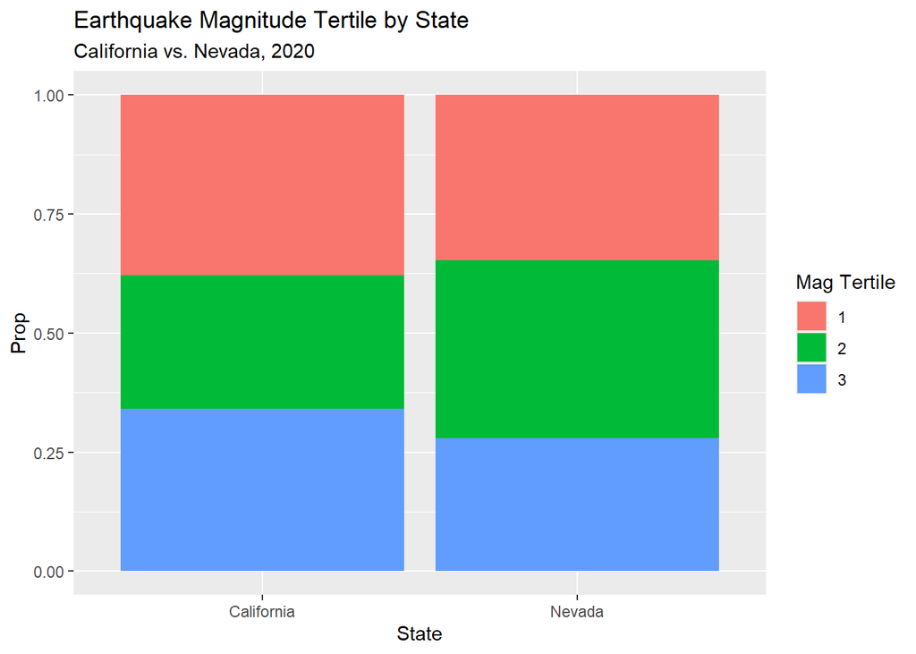

For the above graph, notice that I have hidden the code from you! But you can see it if you look at the **.qmd** file instead of the **.html** rendered file.

You can enter the option `#| echo:false` as the first line of a code chunk to have the code not be displayed, but be executed. There are many other options of this kind.

### Statistical inference

To assess whether there is a significant association between magnitude tertile and state, we employ a chi-squared test of independence.

```r
chisq.test(x=CA_NV_Quakes$state, y=CA_NV_Quakes$magTert)
```

```
    Pearson's Chi-squared test

data:  CA_NV_Quakes$state and CA_NV_Quakes$magTert
X-squared = 1.9645, df = 2, p-value = 0.3745
```

There is insufficient sample evidence to conclude that California and Nevada differ in terms of the distribution of their earthquake magnitudes, when measured by magnitude tertile (stat = 1.96; p-value = 0.3745).

Note: (i) I did not type the numbers 1.96 and 0.3745 in my text above. I had R evaluate them automatically. Again, this is nice when you have errors in your analysis or code. If you have your text automated and linked to your R data objects, you don’t need to redo text based on corrected errors. (ii) There is a hidden code chunk in the Quarto document that evaluates but does not display the code nor the output. I just used it to create an R data object with the chi-squared analysis results in it.

*The End*

**The End**

*The End*

The End

See https://quarto.org/docs/authoring/markdown-basics.html for some common markdown elements to include in your R Quarto documents.